# 認知科学会第35回大会 オーガナイズドセッション

# 意味理解とオブジェクト認知 : ホモ・クオリタスとしての人間理解へ向けて

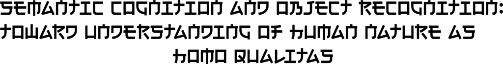

- 日程 | 2018年8月30日（木）16:10-18:40
- 会場 | A棟2F AC232
- 企画 | 日髙昇平（北陸先端科学技術大学院大学）・高橋康介（中京大学）
- Web | http://www.jcss.gr.jp/meetings/jcss2018/program.php#0009

## プレゼンター

(alphabetical order)

- [日高昇平 (北陸先端科学技術大学院大学；認知科学、計算理論、意味認知)](http://www.jaist.ac.jp/~shhidaka/)
- [鳴海拓志 (東京大学；知能情報学、バーチャルリアリティ、拡張現実感の技術)](http://www.cyber.t.u-tokyo.ac.jp/~narumi/)
- [西尾慶之 (東京都立松沢病院；神経内科学、精神医学、幻視の神経解剖学)](https://scholar.google.com/citations?user=Za5HHAUAAAAJ&hl=en)
- [西郷甲矢人 (長浜バイオ大学；数学、非可換確率論、圏論)](http://www.nagahama-i-bio.ac.jp/research/%E6%95%99%E5%93%A1%E3%81%AE%E7%B4%B9%E4%BB%8B%EF%BC%88%E8%A5%BF%E9%83%B7-%E7%94%B2%E7%9F%A2%E4%BA%BA%EF%BC%89/)
- [高橋康介 (中京大学；知覚心理学、認知心理学、アニマシー知覚、錯視・錯覚)](http://kohske.github.io/chukyo/)

## 概要

我々が自動車を運転をするとき、ハンドルを持つ手やブレーキを踏む足を意識することなく、“自分を拡張した自動車”全体を導くことに専念できる。これはハンドルを持つ手やブレーキを踏む足と、自動車の動きが統合され、高精度の予測可能性を持つことで生じる一体性を反映していると考えられる。つまり、“自分の体のよう”に道具を操ることで、身体を拡張するとも言える。

一方で、こうも考えられる：我々の身体そのもの、あるいはそう捉える認識そのものも、ある場面で遂行しようとする目的の一通過点であり手段にすぎず、その目的達成のために高度に一体として機能するはずである。言い換えれば、いわゆる身体性は、物理的・生物的な筋骨格構造などの性質ではなく、「一体として機能する意味的なまとまり」として再解釈できるだろう。つまり、我々の認識や意識の座と目される脳を取り囲み、神経系からの指令によって動く、という物理的・生物的な制約ゆえに身体が特別なのではなく、我々が達成しようとする目的・目標への(意識を要しないが、手段として不可欠な)経由点として偶々そこにあるに過ぎない。

こうした立場では、身体性や身体イメージの拡張などの付随的な現象ではなく、いかに一体性が成し遂げられるか、あるいは仮に我々が“目的”、“目標”と呼んでいる意味の単位としてのオブジェクト(対象)を以下に定義すべきか、と言った点が主要な問題として浮かび上がる。

本OSでは、こうした問題意識を念頭に、気鋭の論客を招待し、計算論的な立場、心理学的な知見からの示唆、あるいはバーチャルリアリティ(VR)等の技術発展などを踏まえ、テーマを絞ったオープンディスカッションを行う。

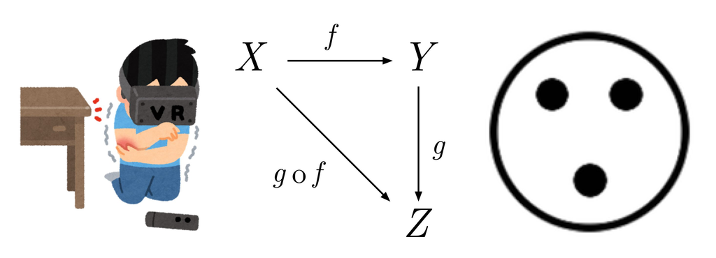

## プログラム

### イントロ（15分）

- 16:10 - 16:25 日髙昇平・高橋康介 「意味理解とオブジェクト認知:ホモクオリタスとしての人間理解に向けて」

### ゲストトーク（3 x 15分）

- 16:25 - 16:40 西尾慶之 「病的知覚体験と他者の表象」
- 16:40 - 16:55 西郷甲矢人「意味の圏論的理解:不定自然変換理論の試み」
- 16:55 - 17:10 鳴海拓志「バーチャルリアリティに見る都合の良い自分」

### VR体験（30分）

- 17:10 - 17:40 高橋康介・鳴海拓志「バーチャルリアリティを通した『意味』の理解」[^1]

### パネルディスカッション（40分）

- 17:40 - 18:20 日高・高橋・西尾・西郷・鳴海「意味理解とオブジェクト認知」

### 総合ディスカッション（20分）

- 18:20-18:40 総合ディスカッション
[^1]: ハコスコを使ったVR体験を予定しています。要スマホ・Wifi接続・Youtubeアプリ。